# Inspecting data

```r
rm(amoris_men)
rm(amoris_women)
rm(correlations_pearson)
rm(correlations_pearson_m)
rm(correlations_pearson_f)
rm(correlations_spearman)
rm(correlations_spearman_m)
rm(correlations_spearman_f)
```

Now we know which biomarkers to use in the BA analysis

```r
#We will now redefine our biomarkers to this combination
#over both 0.10 separately for both men and women, 25-75:
#biomarkers = c("S_Alb", "S_Krea", "TC", "TG", "S_Urea", "S_LD", "S_Ca", "S_FAMN", "S_Hapt", "fS_Gluk")

##new
#biomarkers = c("S_Alb", "S_Krea", "TC", "TG", "S_K", "S_Urea", "S_LD", "S_Ca", "S_Urat", "S_FAMN", "S_Hapt", "fS_Gluk")
```

Scatter plot (with 10% of the cohort)

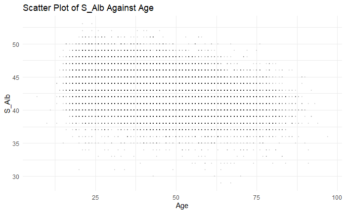

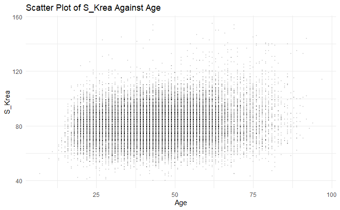

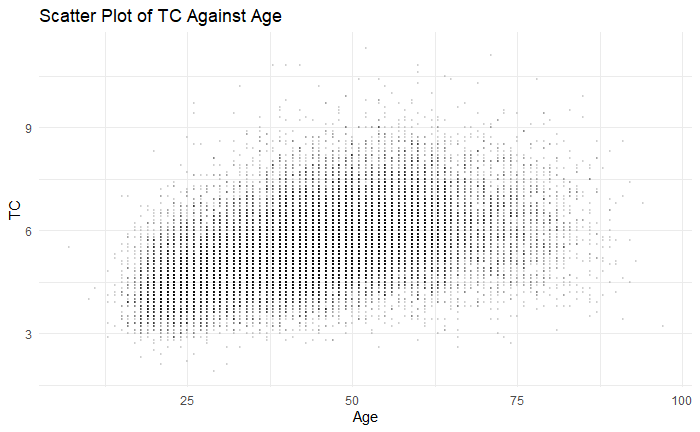

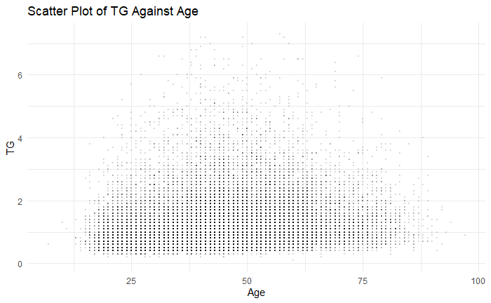

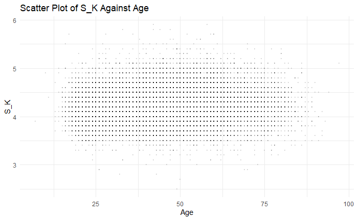

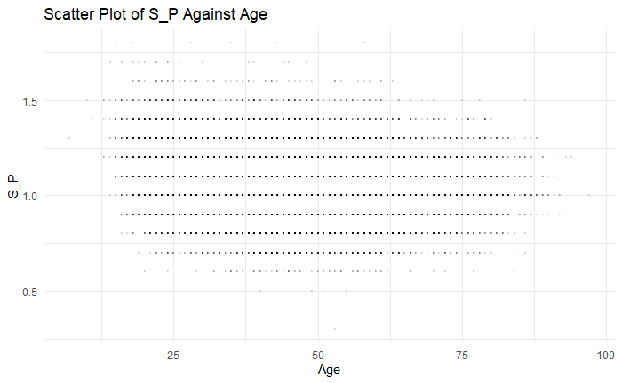

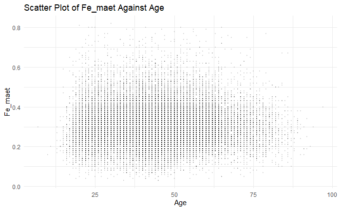

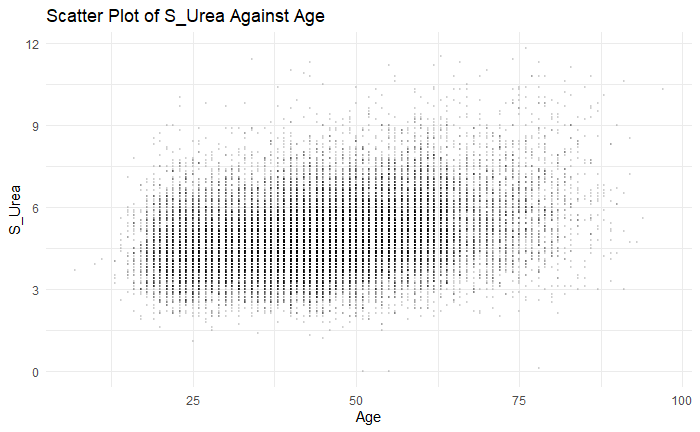

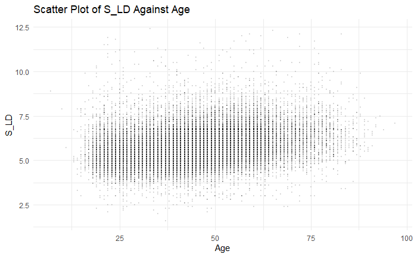

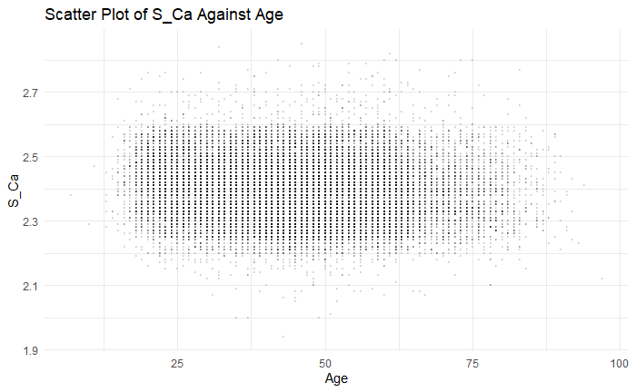

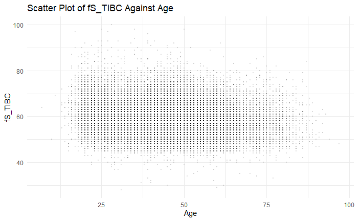

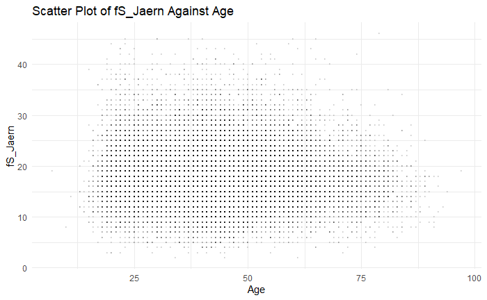

[5 more figures not shown]

```r
# Calculate 10% of the number of patients
sample_size <- floor(0.10 * nrow(AMORIS))

# Randomly sample patient rows
sampled_AMORIS <- AMORIS[sample(nrow(AMORIS), size = sample_size), ]

# Loop through each biomarker and create a scatter plot
for (biomarker in biomarkers) {
  long_data <- sampled_AMORIS %>%
    select(Alder, all_of(biomarker)) %>%
    pivot_longer(
      cols = -Alder, # Exclude the age column from reshaping
      names_to = "biomarker",
      values_to = "value"
    )

  # Create scatter plot for each biomarker
  plot <- ggplot(long_data, aes(x = Alder, y = value)) +
    geom_point(alpha = 0.1, size = 0.1) +
    theme_minimal() +
    labs(x = "Age", y = biomarker, title = paste("Scatter Plot of", biomarker, "Against Age"))

  print(plot) # Print the plot
}
```

```r
rm(sampled_AMORIS)
rm(long_data)
rm(biomarker)
rm(number_of_biomarkers)
rm(sample_size)
```

Figuring out the size of our training set

```r
### Training on a amoris subset the same size as nhanes 3, in the range 25-75
## Figure out number of nhanes participants and participants in range 25-50
load("W:/C6_AmorisGuest/Sara Hagg/Karolina Gustavsson/BioAge-master/BioAge/data/NHANES3.rda")
# Checking the size of 25-75, and 30-75 NHANES people
# lets check the size!
count_df <- NHANES3[NHANES3$age >= 30 & NHANES3$age <= 75, ]
# Count the number of rows in the filtered dataframe
num_rows <- nrow(count_df)
num_rows
```

```
[1] 12535
```

```r
# okay so number of people in 25-75 in nhanes3 is 14377
# okay so number of people in 30-75 in nhanes3 is 12535, which is what they trained on, we also want this amount
```

Let’s look at the other variables: - Economic variables - BMI - Education level

Let’s start with economic variables: DispInk, DispInkFam, DispInkKE, ArbInk (before dementia)

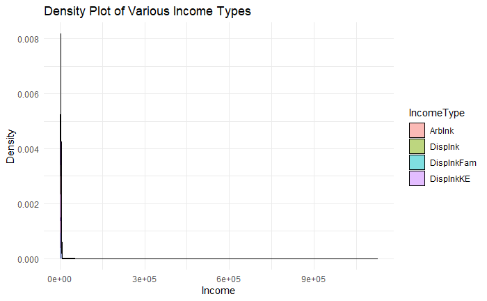

```r
library(ggplot2)
library(tidyr)

# Reshaping the data to long format for easy plotting
AMORIS_long <- AMORIS %>%
  select(DispInk, DispInkKE, DispInkFam, ArbInk) %>%
  pivot_longer(cols = everything(), names_to = "IncomeType", values_to = "Income")

# Density plot of raw data
ggplot(AMORIS_long, aes(x = Income, fill = IncomeType)) +
  geom_density(alpha = 0.5,na.rm = TRUE) +
  labs(title = "Density Plot of Various Income Types", x = "Income", y = "Density") +
  theme_minimal()
```

```r
print("done")
```

```
[1] "done"
```

Okay so we have some very extreme outliers, we can not use average/STD, we have to use median/MAD

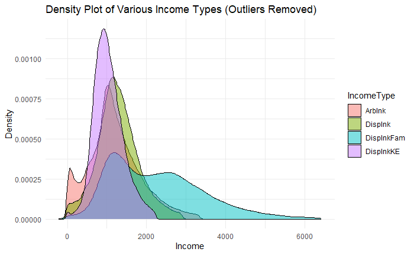

```r
library(ggplot2)
library(dplyr)
library(tidyr)

# Assuming these are your income variables
income_vars <- c("DispInk", "DispInkKE", "DispInkFam", "ArbInk")

# Reshape and then filter outliers based on median and MAD
AMORIS_filtered <- AMORIS %>%
  select(all_of(income_vars)) %>%
  pivot_longer(cols = everything(), names_to = "IncomeType", values_to = "Income") %>%
  group_by(IncomeType) %>%
  mutate(
    median_income = median(Income, na.rm = TRUE),
    mad_income = mad(Income, constant = 1, na.rm = TRUE)  # MAD as a robust measure
  ) %>%
  filter(between(Income, median_income - 5 * mad_income, median_income + 5 * mad_income)) %>%
  ungroup() %>%
  select(-median_income, -mad_income)

# Density plot of data with outliers removed
ggplot(AMORIS_filtered, aes(x = Income, fill = IncomeType)) +
  geom_density(alpha = 0.5, na.rm = TRUE) +
  labs(title = "Density Plot of Various Income Types (Outliers Removed)", x = "Income", y = "Density") +
  theme_minimal()
```

BMI

```r
sum(!is.na(to1po2$BMI)) #not that many cases 32 685
```

```
[1] 32685
```

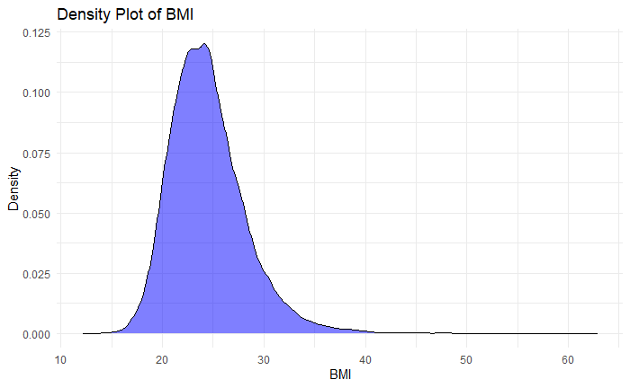

```r
ggplot(AMORIS, aes(x = BMI)) +
  geom_density(fill = "blue", alpha = 0.5, na.rm = TRUE) +
  labs(title = "Density Plot of BMI", x = "BMI", y = "Density") +
  theme_minimal()
```

Distribution per age

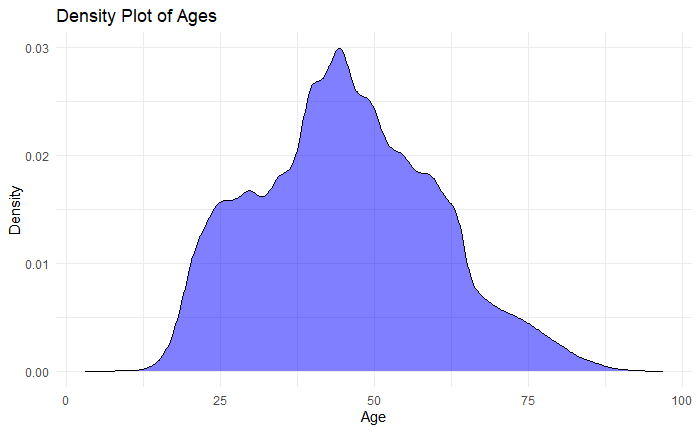

```r
ggplot(AMORIS, aes(x = Alder)) +
  geom_density(fill = "blue", alpha = 0.5) +
  labs(title = "Density Plot of Ages", x = "Age", y = "Density") +
  theme_minimal()
```

Education level

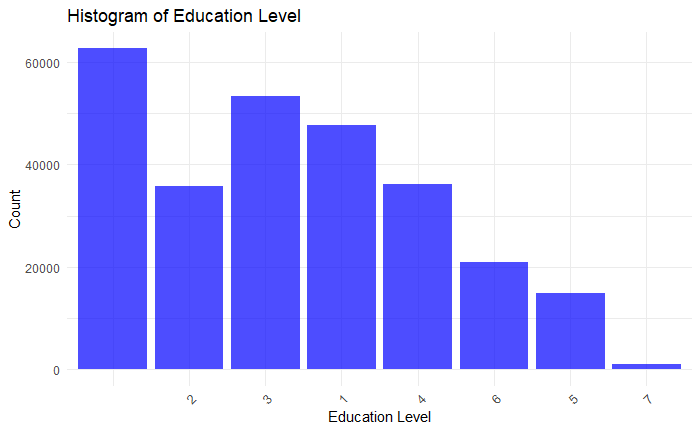

```r
library(ggplot2)

# Convert the education level to a factor, treating empty strings as a separate level
AMORIS$UtbNiva <- factor(AMORIS$UtbNiva, levels = unique(AMORIS$UtbNiva))

# Create a bar plot for education levels
ggplot(AMORIS, aes(x = UtbNiva)) +
  geom_bar(fill = "blue", alpha = 0.7) +
  labs(title = "Histogram of Education Level", x = "Education Level", y = "Count") +
  theme_minimal() +
  theme(axis.text.x = element_text(angle = 45, hjust = 1))  # Adjust the x-axis text angle for better readability
```

Summary statistics

```r
# Identify continuous (numeric) variables
continuous_vars <- sapply(AMORIS, is.numeric) & !sapply(AMORIS, is.factor)

# Custom summary function including standard deviation
custom_summary <- function(x) {
  c(Mean = mean(x, na.rm = TRUE),
    SD = sd(x, na.rm = TRUE),
    Median = median(x, na.rm = TRUE),
    '1st Qu' = quantile(x, probs = 0.25, na.rm = TRUE),
    '3rd Qu' = quantile(x, probs = 0.75, na.rm = TRUE),
    Min = min(x, na.rm = TRUE),
    Max = max(x, na.rm = TRUE))
}

# Apply custom summary function to each continuous variable
summary_stats <- lapply(AMORIS[continuous_vars], custom_summary)

# Convert the list to a dataframe for a cleaner presentation
summary_df <- do.call(rbind, summary_stats)

# View the summary statistics
print(summary_df)
```

[output not shown]

```r
rm(AMORIS_long)
rm(AMORIS_filtered)
rm(income_vars)
rm(agevar)
rm(agevar_ap)
rm(label)
rm(label_ap)
```

Checking out SveDem data

```r
SveDem <- read_sas("W:/C6_AmorisGuest/Sara Hagg/Karolina Gustavsson/Data/SveDem.sas7bdat")
SveDem_format <- read_sas("W:/C6_AmorisGuest/Sara Hagg/Karolina Gustavsson/Data/SveDem_fomats.sas7bdat")
```

Checking out the Svedem unique codes

```r
number_of_unique_strings <- length(unique(SveDem$Dementia))
print(number_of_unique_strings) # 26 unique codes, it says 27 but one is the empty chr str
```

```
[1] 27
```

```r
unique_strings <- unique(SveDem$Dementia)
print(unique_strings)
```

```
 [1] "G308"  ""      "F019"  "G301"  "F013"  "F023"  "F039"  "F002"  "F012"  "G300"  "F011"  "311X"  "F001"  "G318A"
[15] "G309"  "F020"  "F018"  "F009"  "F051"  "F028"  "G311"  "F000"  "F03-P" "F010"  "290B"  "F024"  "290A"
```

```r
K_Svedem_ADRD <- c("G308", "F019",  "G301",  "F013",  "F023",  "F039",  "F002",  "F012",  "G300",  "F011",  "311X",  "F001", "G318A", "G309",  "F020",  "F018",  "F009",  "F051",  "F028",  "G311",  "F000",  "F03-P", "F010",  "290B",  "F024", "290A")
K_Svedem_Alzheimers <- c("304", "290",  "290A", "F00", "305",   "290B", "G30", "311A")
K_Svedem_Vascular <- c("293",   "290E", "F01", "293,1")
K_Svedem_Other <- c("306",  "290X", "F02", "290W",  "F03", "294B",  "G311", "311B", "G318A", "311C",    "F051", "311X")

#more categories
```

Do we have entires in SveDem where Dementia diagnosis is not added to amoris?

```r
# Step 1: Find Matching IDs
matching_ids <- intersect(amoris$Id, SveDem$Id)

# Step 2: Merge Data based on Matching IDs
merged_data <- merge(amoris[amoris$Id %in% matching_ids, c("Id", "Dementia")],
                     SveDem[SveDem$Id %in% matching_ids, c("Id", "Dementia")],
                     by.x = "Id", by.y = "Id")

# Step 3: Compare 'Dementia' Columns
# Assuming the Dementia columns are named Dementia.x and Dementia.y after merging
mismatches <- merged_data$Dementia.x != merged_data$Dementia.y

# Step 4: Count Mismatches
num_mismatches <- sum(mismatches)
print(paste("Number of unmatched Dementia entries:", num_mismatches))
```

```
[1] "Number of unmatched Dementia entries: 0"
```

```r
# Okay so we already have them all, SveDem has more accurate diagnosis so we should run separate SveDem Diagnosis
```

Optional

```r
rm(amoris)
rm(AMORIS)
rm(biomarkers)
```